# Milestone #4

Group 22: Jaemie Anne Abad, Vig Karthik, Kathy LeBert

2023-11-20

## Introduction

Our project continues with the two CalEnviroScreen (CES) datasets from 2021 (“scores” and “measures”) and the California Health and Human Services (CHHS) asthma emergency department (ED) visit rates dataset from 2020.

## Milestone #2 Summary

As a summary of what was accomplished in Milestone #2, we imported the three datasets into R, renamed the column names for ease of analysis, and identified some variables of interest to use in our analysis. We ran summary statistics in our initial exploration of the data. The datasets contain rows of observations by census tract, which are further categorized into counties. While this level of granularity in location is appreciated, our team wishes to match asthma ED visit rates with the CES scores. The asthma ED visit rates are only at the county level, leading to the need to aggregate census tracts into the county level to match up the datasets for further analysis.

## Milestone #3 Summary

In Milestone #3, we finished subetting and cleaning the data, as well as identified any missing variables. We also converted the census tract-level data into county averages so that the data analysis can be done at the county level. We added variables regarding different categories of race and age, as we hoped that the analysis of racial disparities or age-related disparities can provide good evidence for any environmental health interventions to be formed in the near future.

We re-calculated the quartiles for the CES datasets, now based on county data instead of census tract data. We filtered, stratified, and created datasets based on our exposures of interest: age (child vs. adult), race (White vs. Non-White), and also summarized means of two CES measures of interest (Pollution and Housing Burden).

We created a new data dictionary with terms and definitions of variables used in our analysis. Due to feedback, we will update our data dictionary code to be more comprehensive.

We analyzed county-level CES scores, Pollution Burden Score, and Housing Burden Percentage. We then looked at age and asthma rates, comparing the rates for adults and children, and then using the proportions to calculate the weighted state ED admission rates for adults and children. The final tables of our analysis are included below.

We attempted to analyze the asthma ED visit rates by race but ran into issues due to the year mismatch between the datasets. We found that there were certain values where the non-white asthma visit rates were larger than the non-white population of the county, and may need to revise our plan of race-focused analysis.

## Milestone #4 Code

### Data Dictionary Update

We have updated our data dictionary code to be more comprehensive as well as to better reflect the joined dataset.

```r
library(kableExtra)

new_data_dictionary <- data.frame(
variables <- c('2020 Asthma ED visits, 2019 Census, and environmental burden summary','County', 'CES 4.0 Score', 'CES_score_quartile_range', 'Total Population', 'white_prct', 'white_pop',
               'non_white_prcp', 'non_white_pop', 'pop_under_10_prct', 'pop_under_10', 'pop_over_10_prct','pop_over_10',
               'Pollution Burden', 'Pollution Burden Score','Pollution Burden Pctl', 'Housing Burden', 'Housing Burden Pctl',
               'adult_asthma_ed_visits','child-asthma_ed_visits','age-adjusted_ed_visit_rate','white_asthma_ed_visits','non_white_asthma_ed_visits','White', 'Black', 'Hispanic', 'Asian/PI', 'AI/AN','NHPI', 'Multi-race'),
descriptions <- c('Data dictionary','California counties', 'CalEnviroScreen Score','CES 4.0 score grouped by quartile range of scores', '2019 ACS population estimates in census tracts', 'percetange of population that identify as white', 'estimated raw number of population that identify as white, calculated by multiplying percentage to total population', 'percentage of population that identify as non-white or multiple race, calculated by summming percentages of all non-white races and others/multile race from raw demographic results in census tract', 'estimated raw number of population that identify as non-white or multiple race, calculated by multiplying percentage to total population', 'percentage of population that is less than 10 years old','estimated raw number of population that is less than 10 years old, calculated by multiplying percentage to total populaiton', 'percentage of population that is more than 10 years old, calculated by summing population 10 to 64 years and over 64 years', 'estimated raw number of population that is more than 10 years old, calculated by multiplying percentage to total population','Average of percentiles from the Pollution Burden indicators (with a half weighting for the Environmental Effects indicators)','Pollution Burden variable scaled with a range of 0-10. (Used to calculate CES 4.0 Score)','Pollution burden percentile','Percent housing burdened low income households', 'Housing burden percentile','number of Emergency Department (ED) visits due to asthma for those over 18 years of age', 'age adjusted ED visit rates due to asthma, rate per 10,000 residents', 'number of ED visits due to asthma for those under 18 years of age', 'number of ED visits due to asthma for those that identify as white', 'number of ED visits due to asthma for those that identify as non-white or multiple race','White (non-Hispanic) race','Black race','Hispanic race','Asian/Pacific Islander race','American Indian/Alaskan Native race','Native Hawaiian/Pacific Islander race', 'Multiple races'))

colnames(new_data_dictionary)[1] = "VARIABLE"
colnames(new_data_dictionary)[2] = "DESCRIPTION"

new_data_dictionary <- new_data_dictionary %>%
  kbl () %>%
  kable_paper(full_width = F) %>%
  column_spec(1, bold = T, border_right = T) %>%
  column_spec(2, width = "30em")

new_data_dictionary
```

[output not shown]

### Final Dataset Preparation

We have prepared the final dataset, titled data_final_with_race, by starting with the county CES measures and scores from data_final and then adding race-based asthma Emergency Department (ED) visit rate data by using the pivot wider function from the asthma dataset. Thus, data_final_with_race contains 58 observations, one for each of the 58 California counties, for the variables of interest selected from the “asthma” (CHHS), “measures” (CES), and “scores” (CES) datasets.

In addition, we created a dataframe titled race_data_state that shows the statewide asthma ED visit rates by race. The asthma ED visit rates among Black residents is the highest at 89.9 per 10,000 residents, which is almost 5 times as high as the asthma ED visit rate for White residents at 18.3 per 10,000 residents. This data demonstrates that Black Californians are at higher risk of being affected by severe asthma exacerbations requiring hospitalizations compared to other races. Therefore, public health interventions must be done to alleviate this disproprotionate burden. Our team will continue to explore the impacts of race on asthma and its implications for developing interventions.

```r
asthma_race_white <- filter(asthma_2020_race, strata_name == "White") %>%
  pivot_wider(names_from = "strata_name", values_from = "age-adjusted_ed_visit_rate") %>%
  select(county, White)

asthma_race_black <- filter(asthma_2020_race, strata_name == "Black")%>%
  pivot_wider(names_from = "strata_name", values_from = "age-adjusted_ed_visit_rate") %>%
  select(county, Black)
asthma_race_hispanic <- filter(asthma_2020_race, strata_name == "Hispanic") %>%
  pivot_wider(names_from = "strata_name", values_from = "age-adjusted_ed_visit_rate") %>%
  select(county, Hispanic)
asthma_race_AAPI <- filter(asthma_2020_race, strata_name == "Asian/PI") %>%
  pivot_wider(names_from = "strata_name", values_from = "age-adjusted_ed_visit_rate") %>%
  select(county, "Asian/PI")
asthma_race_AI <- filter(asthma_2020_race, strata_name == "AI/AN") %>%
  pivot_wider(names_from = "strata_name", values_from = "age-adjusted_ed_visit_rate") %>%
  select(county, "AI/AN")
asthma_race_NHPI <- filter(asthma_2020_race, strata_name == "NHPI") %>%
  pivot_wider(names_from = "strata_name", values_from = "age-adjusted_ed_visit_rate") %>%
  select(county, NHPI)
asthma_race_MR <- filter(asthma_2020_race, strata_name == "Multi-race") %>%
  pivot_wider(names_from = "strata_name", values_from = "age-adjusted_ed_visit_rate") %>%
  select(county, "Multi-race")

reduced <- Reduce(function(...) merge(..., by='county', all.x=TRUE),
                  list(asthma_race_white,asthma_race_black,asthma_race_hispanic,
                       asthma_race_AAPI,asthma_race_AI,
                       asthma_race_NHPI, asthma_race_MR))

data_final_tojoin <- data_final %>% mutate(County = str_remove_all(County, " COUNTY")) %>%
  rename(county = County)

data_final_with_race <- inner_join(reduced, data_final_tojoin, by = "county")
head(data_final_with_race)
```

```
##      county White Black Hispanic Asian/PI AI/AN NHPI Multi-race
## 1   ALAMEDA  13.1  89.8     23.4     11.7     0 59.8       20.7
## 2    ALPINE   0.0   0.0      0.0      0.0     0  0.0        0.0
## 3    AMADOR  37.6   0.0      0.0      0.0     0  0.0        0.0
## 4     BUTTE  21.4 134.4     19.7     15.6     0  0.0        0.0
## 5 CALAVERAS  30.0   0.0     30.2      0.0     0  0.0        0.0
## 6    COLUSA  30.6   0.0     15.2      0.0     0  0.0        0.0
##   Adult Age-Adjusted ED Visit Rate Child Age-Adjusted ED Visit Rate
## 1                             26.4                             24.1
## 2                              0.0                              0.0
## 3                             31.5                             30.3
## 4                             26.2                             18.5
## 5                             31.1                             28.4
## 6                             24.3                             23.2
##   CES 4.0 Score Pollution Burden Score Housing Burden %
## 1      22.71777               4.557207         15.75250
## 2      13.61516               4.058751         17.40000
## 3      20.74498               4.477942         14.75556
## 4      21.70322               4.199011         18.02941
## 5      14.49627               3.519016         14.63000
## 6      26.98990               5.090508         10.62000
```

```r
str(data_final_with_race)
```

```
## 'data.frame':    58 obs. of  13 variables:
##  $ county                          : chr  "ALAMEDA" "ALPINE" "AMADOR" "BUTTE" ...
##  $ White                           : num  13.1 0 37.6 21.4 30 30.6 15 50.3 20.6 26.3 ...
##  $ Black                           : num  89.8 0 0 134.4 0 ...
##  $ Hispanic                        : num  23.4 0 0 19.7 30.2 15.2 28.9 34.1 19.8 34.7 ...
##  $ Asian/PI                        : num  11.7 0 0 15.6 0 0 11.8 0 0 12.9 ...
##  $ AI/AN                           : num  0 0 0 0 0 0 0 0 0 0 ...
##  $ NHPI                            : num  59.8 0 0 0 0 0 91.5 0 0 0 ...
##  $ Multi-race                      : num  20.7 0 0 0 0 0 10.7 0 0 19.4 ...
##  $ Adult Age-Adjusted ED Visit Rate: num  26.4 0 31.5 26.2 31.1 24.3 27.7 38.8 21.5 27.9 ...
##  $ Child Age-Adjusted ED Visit Rate: num  24.1 0 30.3 18.5 28.4 23.2 26.8 45.6 18.1 51.8 ...
##  $ CES 4.0 Score                   : num  22.7 13.6 20.7 21.7 14.5 ...
##  $ Pollution Burden Score          : num  4.56 4.06 4.48 4.2 3.52 ...
##  $ Housing Burden %                : num  15.8 17.4 14.8 18 14.6 ...
```

```r
race_data_state <- filter(reduced, county == 'CALIFORNIA')
race_data_state
```

```
##       county White Black Hispanic Asian/PI AI/AN NHPI Multi-race
## 1 CALIFORNIA  18.3  89.9     24.6     10.5  20.7 53.6       14.1
```

## Visualizations

In this next section, we have prepared visualizations based on our selected variables of interest and the asthma ED visit rates and/or the CES measures. We hope these tables and charts will help us communicate our data analysis findings to others interested in the relationship between asthma, environmental exposures, and socioeconomic measures.

### Tables

#### Table #1: Variables of Interest

We also wanted to see if there were differences in age-adjusted asthma ED visit rates between adults and children across counties. Generally, adults appear to have slightly higher age-adjusted asthma ED visit rates but what is more interesting is that the county level effect seems to be stronger than age. Solano County, for example, has higher age-adjusted asthma ED visit rates for adults than for children but the magnitude of both rates are significantly higher than the rest of the Bay Area. Putting all three tables together, there appears to be significant variation in age-adjusted asthma ED visit rates across counties and racial categories. One possible explanation could be that county is a proxy for race. A future analysis should attempt to correlate census tract-level racial composition data to both pollution burden and age-adjusted asthma ED visit rates.

```r
# San Francisco Bay Area region includes Alameda, Contra Costa, Marin, Napa, San Francisco, San Mateo, Santa Clara, Solano, and Sonoma counties

data_report <- filter(data_final_with_race, county %in% c("ALAMEDA","CONTRA COSTA", "SAN FRANCISCO", "MARIN", "NAPA", "SONOMA", "SOLANO", "SAN MATEO", "SANTA CLARA")) %>% rename(County = county, "Asian/Pacific Islander" = "Asian/PI", "American Indian/Alaskan Native" = "AI/AN", "Native Hawaiian/Pacific Islander" = NHPI)

race_report <- select(data_report, County, White, Black, Hispanic, "Asian/Pacific Islander", "American Indian/Alaskan Native", "Native Hawaiian/Pacific Islander", "Multi-race") %>%
  kable(booktabs=T, align='lccccccc', caption="California All-Ages Asthma Age-Adjusted ED Visit Rate by Race and County, 2020",format.args=list(big.mark=","))

age_report <- select(data_report, County, "Adult Age-Adjusted ED Visit Rate", "Child Age-Adjusted ED Visit Rate") %>%
  kable(booktabs=T, align='lcc', caption="California Adult (18+) vs. Child (0-17) Age-Adjusted ED Visit Rate by County, 2020",format.args=list(big.mark=","))

CES_report <- select(data_report, County, "CES 4.0 Score", "Pollution Burden Score", "Housing Burden %") %>%
  kable(booktabs=T, align='lccc', caption="California CES 4.0 Scores, Pollution Burden Scores, Housing Burden % of Population by County, 2021",format.args=list(big.mark=","))


race_report
```

California All-Ages Asthma Age-Adjusted ED Visit Rate by Race and County, 2020

| County | White | Black | Hispanic | Asian/Pacific Islander | American Indian/Alaskan Native | Native Hawaiian/Pacific Islander | Multi-race |
| --- | --- | --- | --- | --- | --- | --- | --- |
| ALAMEDA | 13.1 | 89.8 | 23.4 | 11.7 | 0 | 59.8 | 20.7 |
| CONTRA COSTA | 15.0 | 98.7 | 28.9 | 11.8 | 0 | 91.5 | 10.7 |
| MARIN | 8.1 | 46.1 | 17.4 | 0.0 | 0 | 0.0 | 0.0 |
| NAPA | 19.7 | 95.1 | 27.4 | 12.2 | 0 | 0.0 | 0.0 |
| SAN FRANCISCO | 9.4 | 100.0 | 25.0 | 7.1 | 0 | 98.9 | 9.2 |
| SAN MATEO | 9.8 | 33.8 | 20.4 | 9.3 | 0 | 36.6 | 6.4 |
| SANTA CLARA | 11.0 | 56.5 | 22.4 | 7.4 | 0 | 50.3 | 5.0 |
| SOLANO | 32.0 | 99.5 | 33.5 | 25.1 | 0 | 154.3 | 17.7 |
| SONOMA | 16.7 | 63.9 | 20.2 | 14.2 | 0 | 78.1 | 0.0 |

```r
age_report
```

California Adult (18+) vs. Child (0-17) Age-Adjusted ED Visit Rate by County, 2020

| County | Adult Age-Adjusted ED Visit Rate | Child Age-Adjusted ED Visit Rate |
| --- | --- | --- |
| ALAMEDA | 26.4 | 24.1 |
| CONTRA COSTA | 27.7 | 26.8 |
| MARIN | 11.8 | 11.7 |
| NAPA | 23.7 | 19.8 |
| SAN FRANCISCO | 15.4 | 19.8 |
| SAN MATEO | 14.6 | 12.2 |
| SANTA CLARA | 15.7 | 11.1 |
| SOLANO | 42.9 | 38.5 |
| SONOMA | 19.6 | 16.4 |

```r
CES_report
```

California CES 4.0 Scores, Pollution Burden Scores, Housing Burden % of Population by County, 2021

| County | CES 4.0 Score | Pollution Burden Score | Housing Burden % |
| --- | --- | --- | --- |
| ALAMEDA | 22.71777 | 4.557207 | 15.75250 |
| CONTRA COSTA | 21.03005 | 4.320851 | 14.65411 |
| MARIN | 9.74749 | 3.748051 | 16.41455 |
| NAPA | 17.50928 | 4.549032 | 13.16750 |
| SAN FRANCISCO | 18.03143 | 4.511215 | 15.62256 |
| SAN MATEO | 16.73203 | 4.408726 | 15.36051 |
| SANTA CLARA | 16.94746 | 4.300909 | 14.79624 |
| SOLANO | 24.25958 | 4.222140 | 15.83437 |
| SONOMA | 14.88064 | 3.907693 | 16.01414 |

#### Table #2: CES Scores Comparison

In this table, we wanted to see how the nine Bay Area counties compare to the state weighted average CES Score. We see that all counties, except for Solano County, have lower CES Scores than the state as a whole. Looking at the raw data, we see significantly higher CES scores outside of the Bay Area. As noted previously, Marin and Sonoma Counties have very good CES scores and are significantly below the state weighted CES average score.

```r
# San Francisco Bay Area region includes Alameda, Contra Costa, Marin, Napa, San Francisco, San Mateo, Santa Clara, Solano, and Sonoma counties

ces_diff <- data.frame(County = data_report$County, ces_4 = data_report$`CES 4.0 Score`)
ces_diff$prct_vs_state <-(100*ces_diff$ces_4/weighted_CES)
colnames(ces_diff) <- c("County", "CES 4.0 Score", "% of weighted CA State CES Score")

kable_ces_diff <- kable(ces_diff, align='lcc', caption="California All-Ages Asthma ED Visit Rate by County in 2020, % of weighted CA State CES Score",format.args=list(big.mark=","))

kable_ces_diff
```

| County | CES 4.0 Score | % of weighted CA State CES Score |
| --- | --- | --- |
| ALAMEDA | 22.71777 | 94.72909 |
| CONTRA COSTA | 21.03005 | 87.69160 |
| MARIN | 9.74749 | 40.64532 |
| NAPA | 17.50928 | 73.01062 |
| SAN FRANCISCO | 18.03143 | 75.18788 |
| SAN MATEO | 16.73203 | 69.76963 |
| SANTA CLARA | 16.94746 | 70.66793 |
| SOLANO | 24.25958 | 101.15821 |
| SONOMA | 14.88064 | 62.04966 |

### Charts

#### Chart #1: CES Score & Asthma

Here is a scatterplot that aims to identify the relationship between CES 4.0 Score and Adult Asthma ED Visit Rates. A regression line has been added at the 95% confidence level to help identify any patterns between pollution and asthma visits. There are two counties that have data only from the CES datasets but none from the CHHS asthma dataset, #1 Alpine County, and #2 Sierra County.

There appears to be a slight positive relationship between CES score and adult asthma visit rates: counties who are measured to have higher environmental and socioeconomic burdens are associated with increased adult asthma ED visits.

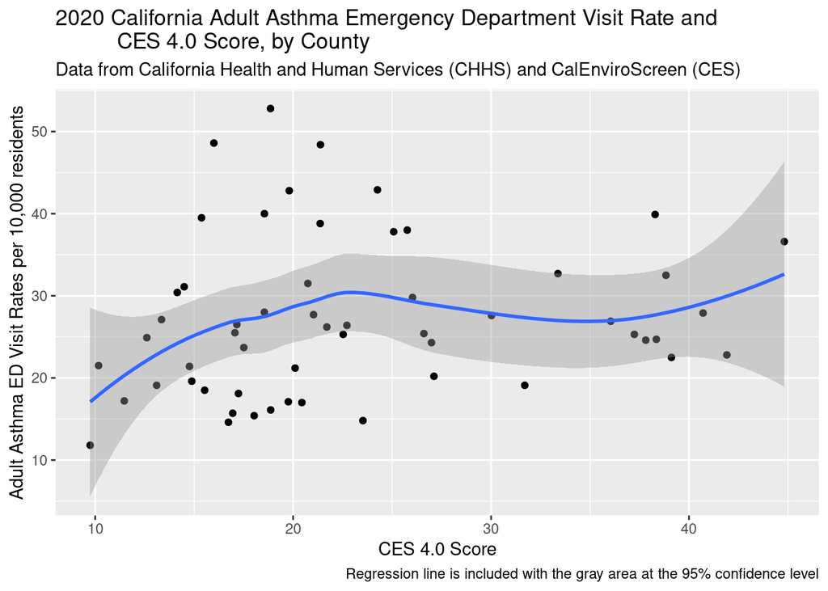

```r
library(ggplot2)

filtered_data_final_with_race <- subset(data_final_with_race, !county %in% c("ALPINE", "SIERRA"))

scatterplot_ces_vs_asthma <- ggplot(filtered_data_final_with_race,
       aes(
         x = as.numeric(`CES 4.0 Score`),
         y = as.numeric(`Adult Age-Adjusted ED Visit Rate`))) +
  geom_point() +
  ggtitle("2020 California Adult Asthma Emergency Department Visit Rate and
          CES 4.0 Score, by County", "Data from California Health and Human Services (CHHS) and CalEnviroScreen (CES)") +
  xlab("CES 4.0 Score") +
  ylab("Adult Asthma ED Visit Rates per 10,000 residents") +
  labs(caption = "Regression line is included with the gray area at the 95% confidence level") +
  geom_smooth(method="auto", se=TRUE, fullrange=FALSE, level=0.95)

scatterplot_ces_vs_asthma
```

#### Chart #2: Pollution & Asthma

This scatterplot aims to identify the relationship between Pollution Burden Score and Adult Asthma ED Visit Rates. Again, a regression line is included at the 95% confidence level, and the two counties without asthma ED visit rate data are excluded (Alpine County and Sierra County).

There does not seem to be a clear relationship between pollution burden and asthma ED visit rates. Therefore, pollution burden may be interacting with asthma ED visit rates in a non-straightforward way. Other variables should be explored to determine what factors play a larger role in asthma visit rates.

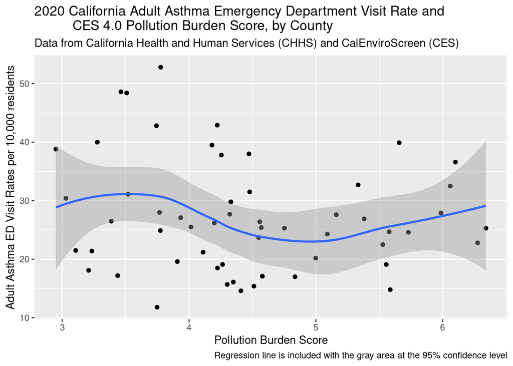

```r
filtered_data_final_with_race <- subset(data_final_with_race, !county %in% c("ALPINE", "SIERRA"))

scatterplot_pollution_vs_asthma <- ggplot(filtered_data_final_with_race,
       aes(
         x = as.numeric(`Pollution Burden Score`),
         y = as.numeric(`Adult Age-Adjusted ED Visit Rate`))) +
  geom_point() +
  ggtitle("2020 California Adult Asthma Emergency Department Visit Rate and
          CES 4.0 Pollution Burden Score, by County", "Data from California Health and Human Services (CHHS) and CalEnviroScreen (CES)") +
  xlab("Pollution Burden Score") +
  ylab("Adult Asthma ED Visit Rates per 10,000 residents") +
  labs(caption = "Regression line is included with the gray area at the 95% confidence level") +
  geom_smooth(method="auto", se=TRUE, fullrange=FALSE, level=0.95)

scatterplot_pollution_vs_asthma
```

#### Chart #3: Housing Burden & Asthma

This next scatterplot aims to identify the relationship between Housing Burden Percent and Adult Asthma ED Visit Rates. Again, a regression line has been added at the 95% confidence level, and counties with no visit rate data (Alpine County and Sierra County) are excluded.

Yet again, there does not seem to be a clear relationship between housing burden and asthma ED visit rates, suggesting that other variables may be more of a factor.

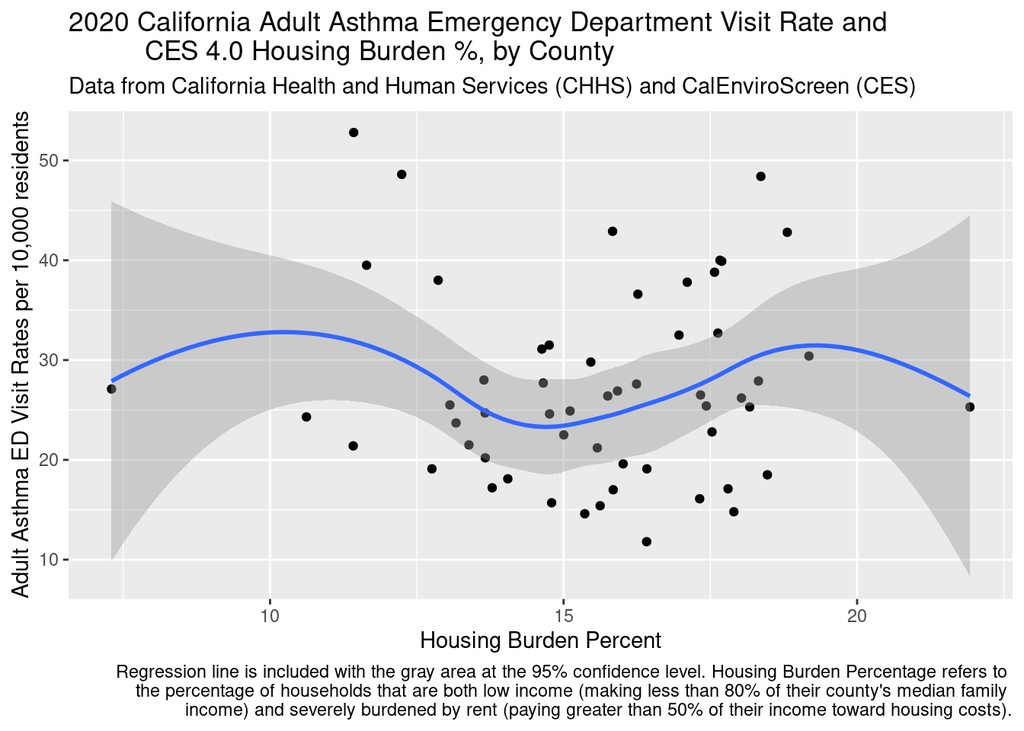

```r
scatterplot_housing_vs_asthma <- ggplot(filtered_data_final_with_race,
       aes(
         x = as.numeric(`Housing Burden %`),
         y = as.numeric(`Adult Age-Adjusted ED Visit Rate`))) +
  geom_point() +
  ggtitle("2020 California Adult Asthma Emergency Department Visit Rate and
          CES 4.0 Housing Burden %, by County", "Data from California Health and Human Services (CHHS) and CalEnviroScreen (CES)") +
  xlab("Housing Burden Percent") +
  ylab("Adult Asthma ED Visit Rates per 10,000 residents") +
  labs(caption = "Regression line is included with the gray area at the 95% confidence level. Housing Burden Percentage refers to
  the percentage of households that are both low income (making less than 80% of their county's median family
  income) and severely burdened by rent (paying greater than 50% of their income toward housing costs).") +
  geom_smooth(method="auto", se=TRUE, fullrange=FALSE, level=0.95)

scatterplot_housing_vs_asthma
```

#### Chart #4: Age & Asthma

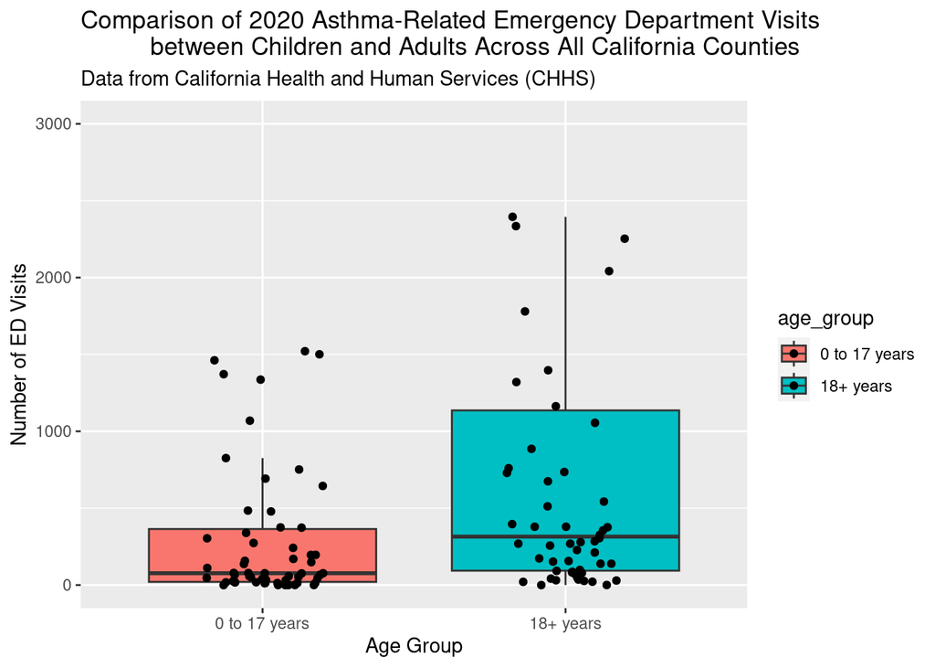

```r
asthma_2020_adult_vs_child <- asthma_2020_age[-c(1,60),]
asthma_2020_adult_vs_child$age_group[asthma_2020_adult_vs_child$age_group != "18+ years"] <- "0 to 17 years"

boxplot <- ggplot(asthma_2020_adult_vs_child, aes(x=age_group, y=number_of_ed_visits, fill = age_group)) +
  geom_boxplot(outlier.shape = NA) +
  coord_cartesian(ylim=c(0,3000))+
  geom_jitter(position=position_jitter(0.2))+
  ggtitle("Comparison of 2020 Asthma-Related Emergency Department Visits
          between Children and Adults Across All California Counties", "Data from California Health and Human Services (CHHS)") +
  ylab("Number of ED Visits") +
  xlab("Age Group")

boxplot
```

#### Chart #5: Race & Asthma

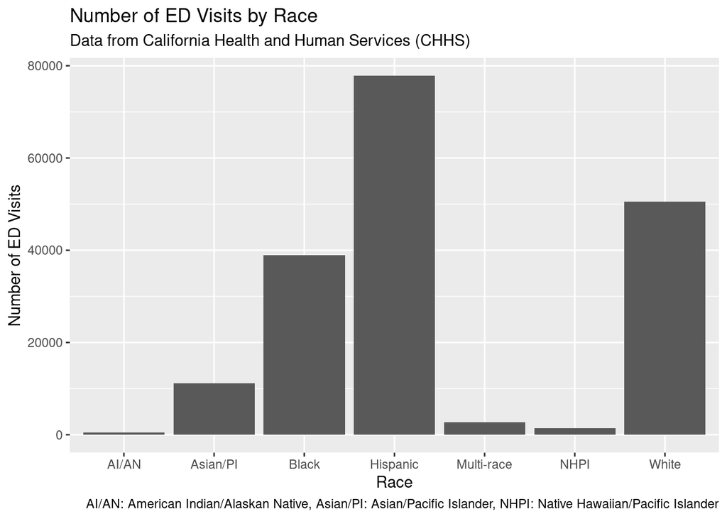

```r
bar_race_asthma <- ggplot(asthma_2020_race, aes(x=strata_name, y=number_of_ed_visits) ) +
  geom_bar(stat="identity") +
  ggtitle("Number of ED Visits by Race", "Data from California Health and Human Services (CHHS)") +
  xlab("Race") +
  ylab("Number of ED Visits") +
  labs(caption = "AI/AN: American Indian/Alaskan Native, Asian/PI: Asian/Pacific Islander, NHPI: Native Hawaiian/Pacific Islander")

bar_race_asthma
```

## Conclusion

We hope these visualizations will help us communicate our findings of the relationships between asthma and environmental or socioeconomic factors. Our team will review these findings and likely revise our analysis to better capture any potential relationships. After further adjustments and research, we hope that our findings can be used to inform asthma-related public health interventions in California and reduce health disparities among age, race, and socioeconomic factors. To make a meaningful impact on the health of Californians with asthma, interventions should be evidence-based and tailored to help the populations experiencing the highest burdens.